# Water Quality Metric Data Analysis

#### Biochemical Oxygen Demand (BOD)

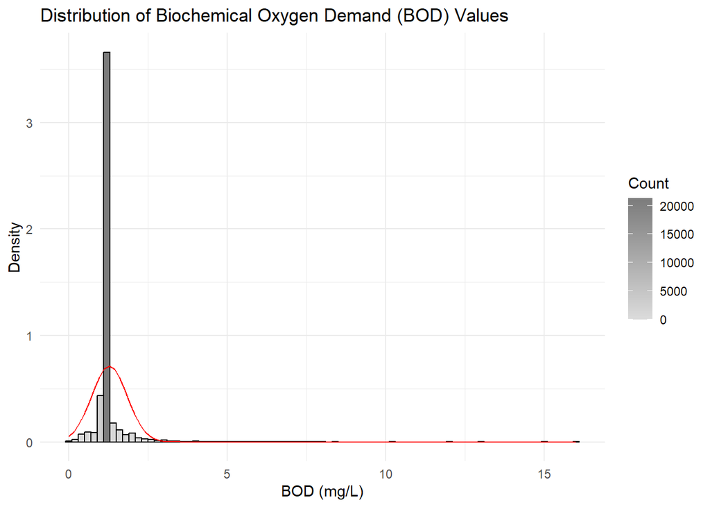

```r
#| label: hist_bod
#| fig.cap: "Figure 5: Histogram of Biochemical Oxygen Demand (BOD) Values"

# create a histogram of ph with density curve over it
gg <- ggplot(wqi_dsubset_clean_t, aes(x = biochem_ox_dmnd))
gg <- gg + labs(
  title = "Distribution of Biochemical Oxygen Demand (BOD) Values",
  x = "BOD (mg/L)",
  y = "Density"
)
# draw the histogram with bin width and colour defined
gg <- gg + geom_histogram(
  binwidth = 0.2,
  colour = "black",
  aes(y = ..density.., fill = ..count..)
)
# set the colour gradient for the histogram
gg <- gg + scale_fill_gradient("Count", low = "#DCDCDC", high = "#7C7C7C")
# creates the normal distribution curve using probability density function
# using the mean and standard deviation from our dataset ph variable
gg <- gg + stat_function(
  fun = dnorm,
  color = "red",
  args = list(
    mean = mean(wqi_dsubset_clean_t$biochem_ox_dmnd, na.rm = TRUE),
    sd = sd(wqi_dsubset_clean_t$biochem_ox_dmnd, na.rm = TRUE)
  )
)
# set the minimal style
gg <- gg + theme_minimal()
# call to dislpay the plot
gg
```

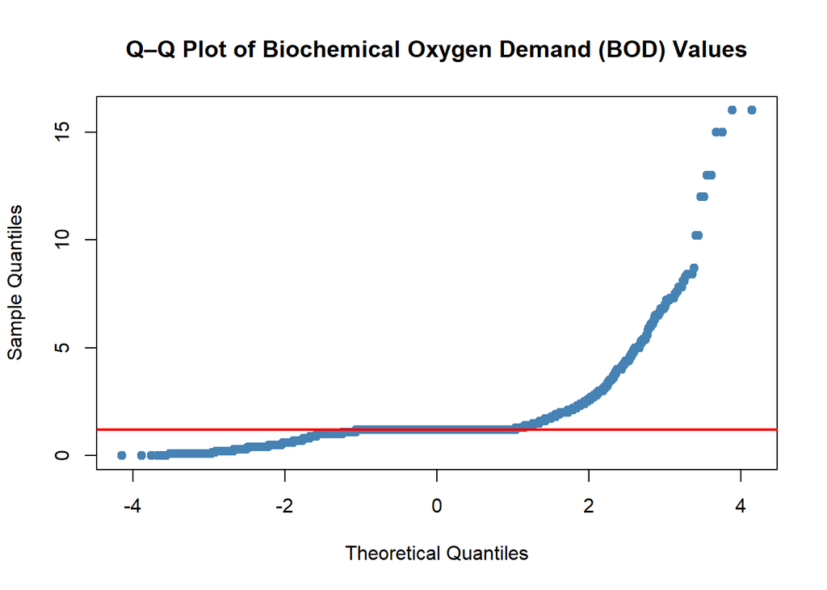

```r
#| label: qq_bod
#| fig.cap: "Figure 6: QQ Plot of Biochemical Oxygen Demand (BOD) Values"

# craete qq plot for temperature
# plots the data quantiles on y axis and theoritical values on x axis
qqnorm(wqi_dsubset_clean_t$biochem_ox_dmnd,
       main = "Q–Q Plot of Biochemical Oxygen Demand (BOD) Values",
       xlab = "Theoretical Quantiles",
       ylab = "Sample Quantiles",
       col = "steelblue",
       pch = 19)
# drawa the comparison line which is standard normal
qqline(wqi_dsubset_clean_t$biochem_ox_dmnd, col = "red", lwd = 2)
```

```r
# use pastec stats describe to get basic statistics
pastecs::stat.desc(wqi_dsubset_clean_t$biochem_ox_dmnd, basic = FALSE)
```

```
      median         mean      SE.mean CI.mean.0.95          var      std.dev
 1.200000000  1.276849009  0.003279281  0.006427539  0.313512867  0.559922197
    coef.var
 0.438518723
```

```r
# will give us mean, sd, median, skew, kurtosis, etc.
psych::describe(wqi_dsubset_clean_t$biochem_ox_dmnd)
```

```
   vars     n mean   sd median trimmed mad min max range skew kurtosis se
X1    1 29154 1.28 0.56    1.2     1.2   0   0  16    16  8.1   119.42  0
```

```r
# Standardized scores for skewness and kurtosis
bod_skew <- semTools::skew(wqi_dsubset_clean_t$biochem_ox_dmnd)
bod_kurt <- semTools::kurtosis(wqi_dsubset_clean_t$biochem_ox_dmnd)
bod_skew_z <- bod_skew[1] / bod_skew[2]
bod_kurt_z <- bod_kurt[1] / bod_kurt[2]

# print otu the standadized skew and kurtosis
cat("Standardised skewness (z):", round(bod_skew_z, 2), "\n")
```

```
Standardised skewness (z): 564.87
```

```r
cat("Standardised kurtosis (z):", round(bod_kurt_z, 2), "\n")
```

```
Standardised kurtosis (z): 4163.14
```

```r
#Calculate percentage of standardized scores for total sleep satisfcation
# are within our limits of +/- 1.96, +/- 3.29
zbod <- abs(scale(wqi_dsubset_clean_t$biochem_ox_dmnd))

# % beyond ±1.96 (approx 5% expected in normal data)
FSA::perc(as.numeric(zbod), 1.96, "gt")
```

```
[1] 3.131646
```

```r
# % beyond ±3.29 (approx 0.1% expected in normal data)
FSA::perc(as.numeric(zbod), 3.29, "gt")
```

```
[1] 1.351444
```

Visual inspection of the Biochemical Oxygen Demand (BOD) histogram indicated a highly positive skew with standardised skewness (z = 564.87) with pronounced leptokurtosis with standardised kurtosis (z = 4163.14). The Q–Q plot indicated a strong right tail, showing a small number of high BOD readings (up to 16) among predominantly low values (mean = 1.27 and median = 1.20 and a standard deviation = 0.55).

To address the skewness and non-normal distribution, we applied a transform to the log10.